# Variable projection fitting of dark adaptation recovery curves

Appendix A to DISC-IP-003: full mathematical treatment

Dr Jeremiah MF Kelly

14 August 2026

# The model

We model the recovery of visual sensitivity during dark adaptation with the function
$$\text{thres}(t) = ct + cc\,e^{-t/\tau} + S2\,(t-\alpha)\,H(t-\alpha),$$
where:

- $\text{thres}(t)$ is the measured threshold at time $t$ after bleach;
- $ct$ is the cone threshold, the plateau to which cone-mediated sensitivity recovers;
- $cc$ is the cone coefficient, the amplitude of the cone recovery component;
- $\tau$ is the cone time constant;
- $S2$ is the slope of the second (rod-mediated) component of recovery;
- $\alpha$ is the rod-cone break, the time at which rod recovery begins;
- $H(t-\alpha)$ is the Heaviside step function, equal to $0$ for $t < \alpha$ and $1$ for $t \geq \alpha$.

The term $(t-\alpha)H(t-\alpha)$ is therefore a ramp: it is zero before the rod-cone break and changes linearly with slope $S2$ after it.

## Rewriting the model in a familiar form

Most STEM scientists are familiar with the equation of a straight line,
$$y = c + mx,$$
where $y$ is the response, $x$ is the independent variable, $c$ is the intercept and $m$ is the gradient. Fitting this line to data by ordinary least squares (OLS) has a closed-form solution: no iteration, no starting guesses.

Our aim is to show that, under one condition, our model has exactly the same character. We want to reach the form
$$\mathbf{Y} = a + \mathbf{B}\,\mathbf{F}(\mathbf{x}),$$
where $\mathbf{Y}$ is the vector of participant responses, $\mathbf{x}$ is the vector of response time stamps, $a$ is an intercept, $\mathbf{F}$ is a set of basis functions evaluated at those time stamps, and $\mathbf{B}$ is a vector of coefficients. This is the straight-line equation with the single term $mx$ replaced by a sum of curved terms.

Suppose the two nonlinear parameters, $\tau$ and $\alpha$, are held fixed. Then define two basis functions:
$$f_1(\mathbf{x}) = e^{-\mathbf{x}/\tau}, \qquad
f_2(\mathbf{x}) = (\mathbf{x}-\alpha)\,H(\mathbf{x}-\alpha).$$
The model becomes
$$\mathbf{Y} = ct + cc\,f_1(\mathbf{x}) + S2\,f_2(\mathbf{x}) = a +
\mathbf{B}\,\mathbf{F}(\mathbf{x}),$$
with $a = ct$ playing the role of the intercept $c$, and $\mathbf{B} = (cc,\ S2)$. This is a linear model. Every quantity we do not know appears only as an intercept or a multiplying coefficient. Those familiar with OLS will recognise that the best-fitting $a$ and $\mathbf{B}$ can be computed together in closed form, exactly as for the straight line.

## The point of variable projection

The full model is non-linear only through $\tau$ and $\alpha$. Variable projection (VarPro) exploits this structure:

1. For any candidate pair $(\tau, \alpha)$, the intercept and coefficients $(ct, cc, S2)$ are obtained analytically by least squares. They are never searched for.
2. The optimisation therefore reduces from a five-parameter nonlinear search to a two-parameter search over $(\tau, \alpha)$ alone.

This separation brings practical benefits. The search space collapses from five dimensions to two, so the fit is faster and far less prone to local minima. No starting guesses are required for the linear parameters, which removes a common source of fitting failure in clinical data. The two-dimensional $(\tau, \alpha)$ space is small enough to search exhaustively over a grid, giving a deterministic and reproducible fit.

# The design matrix

For $n$ observations $(t_i, y_i)$ and a fixed candidate pair $(\tau, \alpha)$, define the $n \times 3$ design matrix
$$A(\tau, \alpha) =
\begin{pmatrix}
1 & e^{-t_1/\tau} & (t_1 - \alpha)H(t_1 - \alpha) \\
\vdots & \vdots & \vdots \\
1 & e^{-t_n/\tau} & (t_n - \alpha)H(t_n - \alpha)
\end{pmatrix},$$
whose columns are the constant, the cone basis function $f_1$, and the rod ramp $f_2$. The inner problem is then ordinary least squares,
$$\hat{\theta}(\tau, \alpha) = \arg\min_{\theta} \lVert \mathbf{Y} -
A(\tau,\alpha)\,\theta \rVert^2,
\qquad \theta = (ct,\ cc,\ S2)^{\top}.$$

In R the matrix is one line; note that $(t-\alpha)H(t-\alpha)$ is simply `pmax(t - alpha, 0)`:

```r
build_A <- function(t, tau, alpha) {
  cbind(1, exp(-t / tau), pmax(t - alpha, 0))
}
```

# The inner solve: normal equations and QR

The textbook solution of the inner problem is via the normal equations,
$$\hat{\theta} = (A^{\top}A)^{-1} A^{\top} \mathbf{Y}.$$
The implementation instead uses the QR decomposition $A = QR$, giving
$$\hat{\theta} = R^{-1} Q^{\top} \mathbf{Y},$$
computed by back-substitution without ever forming $A^{\top}A$.

```r
solve_inner <- function(t, y, tau, alpha) {
  qrA <- qr(build_A(t, tau, alpha))
  list(theta = qr.coef(qrA, y),
       rss   = sum(qr.resid(qrA, y)^2))
}
```

The choice matters because forming $A^{\top}A$ squares the condition number, $\kappa(A^{\top}A) = \kappa(A)^2$, and our design matrix is ill-conditioned in exactly the regimes that occur in practice. When $\tau$ is large relative to the test window, the exponential column flattens towards an affine function of $t$; when $\alpha$ is small, the ramp column is close to an affine function of $t$ as well; together with the constant column the matrix approaches rank deficiency. The following makes the effect concrete:

```r
t_demo <- seq(0, 15, by = 1/3)
A_typical <- build_A(t_demo, tau = 1.2, alpha = 3.8)
A_ill     <- build_A(t_demo, tau = 200, alpha = 0.1)
c(kappa_typical    = kappa(A_typical),
  kappa_ill        = kappa(A_ill),
  kappa_normal_eqs = kappa(crossprod(A_ill)))
```

```
##    kappa_typical        kappa_ill kappa_normal_eqs
##     4.214439e+01     9.739861e+04     3.815582e+09
```

QR works at the condition number of $A$ itself; the normal equations work at its square, which in the ill-conditioned case above is of order $10^9$ and approaching the limit of double precision. Interior grid points are well conditioned; QR ensures the boundary of the grid is handled as accurately as the interior.

# Why it is called projection

The fitted values for a candidate pair are the orthogonal projection of $\mathbf{Y}$ onto the column space of $A(\tau,\alpha)$. Writing $P_{A} = QQ^{\top}$ for the projector, the residual sum of squares that the outer search minimises is
$$r(\tau, \alpha) = \lVert (I - P_{A})\,\mathbf{Y} \rVert^2,$$
the squared length of the component of the data orthogonal to everything the linear parameters can explain. The linear parameters have been projected out of the problem, hence the name. The identity is easily verified numerically:

```r
set.seed(1)
y_demo <- rnorm(length(t_demo))
s  <- solve_inner(t_demo, y_demo, tau = 1.2, alpha = 3.8)
Q  <- qr.Q(qr(build_A(t_demo, tau = 1.2, alpha = 3.8)))
rss_projector <- sum(((diag(length(y_demo)) - Q %*% t(Q)) %*% y_demo)^2)
all.equal(rss_projector, s$rss)
```

```
## [1] TRUE
```

# The outer search

## Grid and bounds

The grid over $(\tau, \alpha)$ is bounded by physiology and protocol, consistent with Section 6 of DISC-IP-003. Operational experience shows the cone time constant is usually below two minutes, so $\tau \in (0, 2]$ min. The range of $\alpha$ is contingent on the flash intensity of the test protocol; a fitted $\alpha$ beyond five minutes indicates an inadequate bleach rather than a physiological result, so $\alpha \in (0, 10]$ min, with the upper bound set here for illustrative purposes, the reported value acts as a validity check on the bleaching stage.

```r
tau_grid   <- seq(0.05, 2.00, by = 0.05)   # 40 values
alpha_grid <- seq(0.50, 10.00, length.out=99)   # 99 values ~ 5.82 seconds
length(tau_grid) * length(alpha_grid)      # total closed-form solves
```

```
## [1] 3960
```

## The loop, cost, and tie-breaking

```r
fit_varpro <- function(t, y, tau_grid, alpha_grid) {
  best <- list(rss = Inf)
  for (tau in tau_grid) for (alpha in alpha_grid) {
    s <- solve_inner(t, y, tau, alpha)
    if (s$rss < best$rss)
      best <- list(theta = s$theta, rss = s$rss, tau = tau, alpha = alpha)
  }
  best
}
```

The cost is exactly one $n \times 3$ QR decomposition per grid cell: fixed, data-independent, and known in advance. This is the appendix-level substantiation of the bounded-cost claim of DISC-IP-003. The strict inequality `s$rss < best$rss` is the tie-break rule: if two cells ever produce identical residuals, the first encountered in the fixed scan order (row-major over `tau_grid` then `alpha_grid`) is kept. The rule is stated so that the determinism claim, identical data yield identical parameters, holds without qualification.

# Numerical demonstration

We simulate a recovery curve with known parameters, sampled at three thresholds per minute over a fifteen-minute test, and fit it with the exhaustive grid at two noise levels: a clinically realistic threshold noise of 0.10 log units, and a low-noise condition of 0.02 log units.

```r
model <- function(t, p) p["ct"] + p["cc"] * exp(-t / p["tau"]) +
  p["S2"] * pmax(t - p["alpha"], 0)

truth <- c(ct = 1.0, cc = 2.0, tau = 1.2, alpha = 3.8, S2 = -0.25)
t_obs <- seq(0, 15, by = 1/3)

set.seed(1)
y_noisy <- model(t_obs, truth) + rnorm(length(t_obs), sd = 0.10)
y_clean <- model(t_obs, truth) + rnorm(length(t_obs), sd = 0.02)

elapsed_noisy <- system.time(
  fit_noisy <- fit_varpro(t_obs, y_noisy, tau_grid, alpha_grid)
)["elapsed"]

elapsed_clear <- system.time(
  fit_clean <- fit_varpro(t_obs, y_clean, tau_grid, alpha_grid)
)["elapsed"]

data.frame(
  parameter        = names(truth),
  truth            = as.numeric(truth),
  fit_sd_0.10      = round(c(fit_noisy$theta[1:2], fit_noisy$tau,
                             fit_noisy$alpha, fit_noisy$theta[3]), 3),
  fit_sd_0.02      = round(c(fit_clean$theta[1:2], fit_clean$tau,
                             fit_clean$alpha, fit_clean$theta[3]), 3),
  row.names = NULL
)
```

```
##   parameter truth fit_sd_0.10 fit_sd_0.02
## 1        ct  1.00       1.085       1.004
## 2        cc  2.00       1.883       2.005
## 3       tau  1.20       1.150       1.200
## 4     alpha  3.80       3.505       3.796
## 5        S2 -0.25      -0.251      -0.250
```

```r
elapsed_noisy
```

```
## elapsed
##   0.139
```

```r
elapsed_clear
```

```
## elapsed
##   0.133
```

```r
t_del <- elapsed_noisy - elapsed_clear
t_del
```

```
## elapsed
##   0.006
```

Two observations. First, the full grid of 3960 closed-form solves completes in a fraction of a second on a laptop in interpreted R; a compiled implementation on device hardware is faster still, and the cost is fixed regardless of the data. Second, the parameters differ in how sharply the data constrain them. The linear parameters and $\tau$ are recovered closely even at clinical noise. The break time $\alpha$ carries the widest uncertainty of the five: the ramp contributes almost nothing to the fit in the neighbourhood of the break, so observations there carry little information about its exact position. At clinical noise the grid recovery is within a few tenths of a minute; at low noise it converges to the truth. This is a property of the estimation problem, not of the method; any fitting procedure faces it, and the exhaustive grid at least guarantees that the reported $\alpha$ is the best available over the whole physiological range.

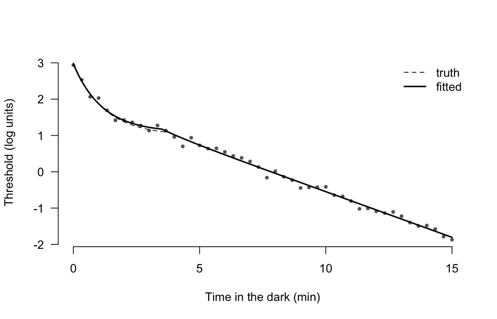

```r
par(las=1, bty = 'n')
plot(t_obs, y_noisy, pch = 16, cex = 0.7, col = "grey40",
     xlab = "Time in the dark (min)", ylab = "Threshold (log units)")
t_fine <- seq(0, 15, by = 0.02)
fitted_p <- c(ct = unname(fit_noisy$theta[1]), cc = unname(fit_noisy$theta[2]),
              tau = fit_noisy$tau, alpha = fit_noisy$alpha,
              S2 = unname(fit_noisy$theta[3]))
lines(t_fine, model(t_fine, truth),    lty = 2)
lines(t_fine, model(t_fine, fitted_p), lwd = 2)
legend("topright", c("truth", "fitted"), lty = c(2, 1), lwd = c(1, 2), bty = "n")
```

# Edge cases

**No break within the test window.** If a candidate $\alpha$ meets or exceeds the largest observation time, the ramp column of $A$ is identically zero and the matrix is rank deficient. R’s rank-revealing QR handles this gracefully, returning `NA` for the unidentifiable coefficient while still fitting the remaining two columns:

```r
solve_inner(t_obs, y_noisy, tau = 1.2, alpha = 20)$theta
```

```
## [1] -0.2397964  4.1567931         NA
```

In the implementation this case is excluded by construction: the grid’s upper bound of ten minutes sits well inside the test window, so every candidate design matrix has full rank. Should a participant genuinely show no break within the window, the best fit lands at the boundary of the grid and is reported as such, flagging the test rather than silently extrapolating.

**Ties.** Covered above: strict inequality with a fixed scan order makes the selection deterministic even in the measure-zero event of equal residuals.

# Determinism and cross-platform reproducibility

The method is deterministic by construction: a fixed grid, a closed-form solve at each cell, and a stated tie-break. On a single platform, identical data yield bit-identical parameters. Across platforms, exact agreement additionally depends on the floating-point summation order inside the linear algebra library, which differs between builds. This section reports a direct measurement of that agreement.

## Design of the comparison

The complete validation experiment was executed on two machines under the same repository commit, verified identical by `git diff`, with the pseudo-random number generator version pinned so that both platforms simulate identical data:

|  | Development platform | Independent platform |
| --- | --- | --- |
| Architecture | arm64 (Apple silicon) | riscv64 (UltraRISC UR-DP1000) |
| Operating system | macOS | Ubuntu |
| R version | 4.5.2 | 4.3.3 |
| BLAS | Accelerate / vecLib | reference BLAS |

The two builds therefore differ in instruction set architecture, operating system, R version, and linear algebra implementation: close to a worst case for exact agreement.

**Inputs are bit-identical.** Under the pinned generator, the same seed produces the same pseudo-random draws on both machines, verified to the last bit by comparing the exact hexadecimal representation of the values (`sprintf("%a", ...)`). Every simulated recovery curve is therefore identical on the two platforms, and any difference in the fitted parameters is attributable to the fitting arithmetic alone.

The comparison covers 191,996 replications: the four cone-time-constant sets in full, on both platforms.

## Results

Fits at the lower bound of the $\tau$ grid are excluded from the parameter comparison and reported separately: there the cone exponential collapses over the sampled interval and the cone coefficient is unidentified, taking values of order $10^{13}$ on both platforms. These accounted for 15,271 replications, 8.0% of the total. Both platforms reached the same degenerate solution in every such case, agreeing to seven significant figures.

Over the remaining 176,725 identified fits:

| Cone time constant $\tau$ | 0.6 | 1.2 | 1.8 | 2.4 |
| --- | --- | --- | --- | --- |
| Identified fits compared | 44,165 | 43,995 | 43,913 | 44,652 |
| Residual sum of squares bit-identical | 76.5% | 76.0% | 75.7% | 75.8% |
| RSS difference, 99th percentile | $1.0\times10^{-14}$ | $1.0\times10^{-14}$ | $1.0\times10^{-14}$ | $1.0\times10^{-14}$ |
| RSS difference, 99.9th percentile | $1.1\times10^{-14}$ | $1.1\times10^{-14}$ | $1.1\times10^{-14}$ | $1.7\times10^{-6}$ |
| Largest RSS difference | $2.2\times10^{-4}$ | $1.2\times10^{-5}$ | $7.1\times10^{-4}$ | $8.0\times10^{-4}$ |
| Break times differing by more than $10^{-6}$ min | 2 | 1 | 4 | 60 |
| Boundary classification disagreements | 0 | 0 | 1 | 0 |

Roughly three quarters of all fits are bit-identical across the two architectures, and the residual sum of squares agrees to $1\times10^{-14}$ in 99% of cases in every cone regime. Classification of the fitted slope as interior or at a bound agreed in 191,995 of 191,996 comparisons: a single disagreement in the whole experiment.

## The source and size of the exceptions

Where the two platforms differ, the difference arises at one specific point in the pipeline, and not in the exhaustive search. In every case examined the two platforms selected the same winning grid cell, with identical grid parameters and grid residual. The divergence occurs in the subsequent continuous refinement, at the test that decides whether the refined solution is accepted:

$$\text{accept if }
\mathrm{RSS}_{\text{refined}} <
\mathrm{RSS}_{\text{grid}}.$$

When the refinement improves the residual only at the level of floating-point rounding, this strict comparison can fall either way, and the two platforms then report the two endpoints of a step that made no material difference to the fit. Across the four sets this occurred in 1, 1, 1, and 53 replications respectively.

**The exceptions concentrate in the ill-conditioned regime.** Both the count of accept-test disagreements (1, 1, 1, 53) and the count of materially differing break times (2, 1, 4, 60) rise by more than an order of magnitude at the longest cone time constant, while the other three regimes remain at one to four. This is expected from the geometry of the problem. When $\tau$ is long relative to the test window, the cone exponential approaches an affine function of time and the error surface develops a ridge along which the parameters trade off; refinement gains along such a ridge are small, so the accept test is more often decided by rounding. The same regime is the only one in which the 99.9th percentile of the residual difference leaves rounding territory at all.

The practical size of the exceptions is negligible. The largest disagreement in break time anywhere in the comparison was 0.43 minutes, in a replication with *no true rod phase* where both platforms returned a fitted slope of about $-0.001$; the remaining worst cases differ by 0.05 to 0.38 minutes, that is, three to twenty-three seconds, against confidence intervals for the break time that are 1.5 to 4 minutes wide. In these replications the residual sums of squares agree to four significant figures or better: the two platforms have found fits of indistinguishable quality and differ only in which of two near-equivalent parameter sets they report.

## Statement

Identical inputs, verified bit-identical across architectures, produce fits that are bit-identical in roughly three quarters of cases and agree to $1\times10^{-14}$ in residual sum of squares in 99% of cases, despite differences in instruction set, operating system, R version, and linear algebra implementation. The exhaustive profiled search itself agreed exactly in every case examined, and the classification of the fitted slope agreed in all but one of 191,996 comparisons. The rare exceptions arise from the accept test of the optional refinement stage when its improvement is at the level of rounding, concentrate in the ill-conditioned cone regime, and are immaterial by any clinical or statistical measure.

If bit-level cross-platform identity were ever required, two routes are available: omitting the refinement stage, which the validation experiment shows contributes a median residual improvement of well under one per cent and parameter shifts of a fraction of a grid step; or replacing the accept test with a tolerance, so that a refinement is accepted only when it improves the residual by more than a stated margin.

# References

- Golub, G.H. and Pereyra, V. (1973). The differentiation of pseudo-inverses and nonlinear least squares problems whose variables separate. *SIAM Journal on Numerical Analysis*, 10(2), 413–432.
- Golub, G.H. and Pereyra, V. (2003). Separable nonlinear least squares: the variable projection method and its applications. *Inverse Problems*, 19(2), R1–R26.
- O’Leary, D.P. and Rust, B.W. (2013). Variable projection for nonlinear least squares problems. *Computational Optimization and Applications*, 54(3), 579–593.
- Lamb, T.D. and Pugh, E.N. Jr (2004). Dark adaptation and the retinoid cycle of vision. *Progress in Retinal and Eye Research*, 23(3), 307–380.

Page ranges verified against `profile_least_squares_references.bib` 14/08/2026.